# Deaths Associated with Neurological Conditions

Evie Massheder

2024-12-10

## Project Description

Data is available from this link:

https://www.gov.uk/government/publications/deaths-associated-with-neurological-conditions

The URL for these pages is:

https://evie-lois.github.io/deaths-assoc-neuro/

The repository for these pages is:

https://github.com/evie-lois/deaths-assoc-neuro.git

## Research Question

Which neurological condition has the highest rate of associated deaths from 2001 to 2014?

## Import Data

```r
# Importing one sheet from Excel workbook as dataset

# Specify the sheet by name from Excel workbook

data <- read.xlsx("/Users/eviemassheder/Documents/Data Analysis and Visualisation/workbook.xlsx", sheet = "Deaths in England")

# Save the sheet to a new Excel file

write.xlsx(data, "/Users/eviemassheder/Documents/Data Analysis and Visualisation/DeathsinEngland.xlsx")

loc = "/Users/eviemassheder/Documents/Data Analysis and Visualisation/DeathsinEngland.xlsx"

data <- read.xlsx(loc)
```

## Data Preparations

```r
#Split embedded table into two

first_table <- data[1:16, ]

second_table <-data[17:nrow(data), ]

# Structure tables, exclude outliers

first_table <- first_table[-c(16), ]

second_table <- second_table[-c(16:31),]

# Swap the first row of each table to the column names

colnames(first_table) <- first_table[1, ]

first_table <- first_table[-1, ]

colnames(second_table) <-second_table[1, ]

second_table <- second_table[-1, ]

# Clean data, removing outliers

data1_cleaned <- first_table[, -c(2,11)]

data2_cleaned <- second_table[, -c(8,10)]

# Combine tables

combined_table <- bind_cols(data1_cleaned, data2_cleaned)
```

[output not shown]

```r
# Clean new dataset

cleaned_dataset <- combined_table[,-c(10)]

#Code columns

cols <- c("year", "dwnc", "epi", "mndsma", "msid", "nmd", "poed", "tbsi", "totns", "at", "cnsi", "cnd", "dd", "fd", "ham", "raond", "smar")

colnames(cleaned_dataset) <- cols

#Reshape the data

reshaped_dataset <- cleaned_dataset %>%
  pivot_longer(cols = -year,
               names_to = "Condition",
               values_to = "Deaths")

#Show cleaned and reshaped dataset

head(reshaped_dataset)
```

```
## # A tibble: 6 × 3
##   year  Condition Deaths
##   <chr> <chr>     <chr>
## 1 2001  dwnc      23051
## 2 2001  epi       1936
## 3 2001  mndsma    1574
## 4 2001  msid      1301
## 5 2001  nmd       563
## 6 2001  poed      6963
```

## Visualisation

```r
# Check 'Deaths' column is numeric for plot

str(reshaped_dataset$Deaths)
```

```
##  chr [1:224] "23051" "1936" "1574" "1301" "563" "6963" "1773" "4995" "80" ...
```

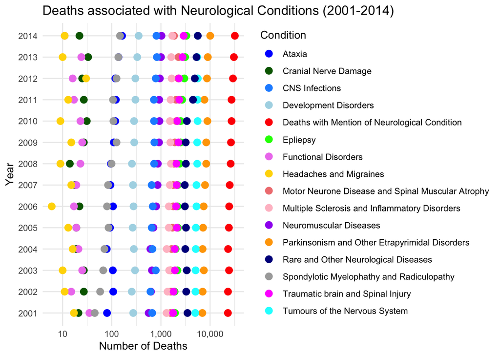

```r
reshaped_dataset$Deaths <- as.numeric(as.character(reshaped_dataset$Deaths))

# Create the scatter plot

ggplot(reshaped_dataset, aes(x = year, y = Deaths, color = Condition)) +
  geom_point(size = 3) +
  labs(title = "Deaths associated with Neurological Conditions (2001-2014)",
       x = "Year",
       y = "Number of Deaths") +
  theme_minimal() +
  scale_y_log10(labels = scales::comma) +

#Colour Code Conditions

  scale_color_manual(values = c( "dwnc" = "red", "epi" = "green", "mndsma" = "lightcoral", "msid" = "pink", "nmd"= "purple", "poed" = "orange", "tbsi" = "magenta", "totns" = "cyan", "at" = "blue", "cnsi" = "dodgerblue", "cnd" = "darkgreen", "dd" = "lightblue", "fd" = "violet", "ham" = "gold", "raond"= "darkblue", "smar" = "darkgray"),

 #Label Disorders

 labels = c( "dwnc" = "Deaths with Mention of Neurological Condition", "epi" = "Epliepsy", "mndsma" = "Motor Neurone Disease and Spinal Muscular Atrophy", "msid" = "Multiple Sclerosis and Inflammatory Disorders", "nmd" = "Neuromuscular Diseases", "poed" = "Parkinsonism and Other Etrapyrimidal Disorders", "tbsi" = "Traumatic brain and Spinal Injury", "totns" = "Tumours of the Nervous System", "at"= "Ataxia", "cnsi" = "CNS Infections", "cnd" = "Cranial Nerve Damage", "dd" = "Development Disorders", "fd" = "Functional Disorders", "ham" = "Headaches and Migraines", "raond" = "Rare and Other Neurological Diseases", "smar" = "Spondylotic Myelophathy and Radiculopathy")) +

# Flip the plot for horizontal view

  coord_flip()
```

```r
#Interactive Plot
```

[output not shown]

## Summary

If I was to do this project again with more time and data accessibility, I would have followed through with my previous choice of public health data looking into a comparison of the Western Diet and Mediterranean Diet. Comparing the effects on life expectancy and disease. I would have chosen data from individuals that follow either diet and compare their health to see if there was a correlation of disease and shorter life expectancy with the Western Diet to understand the effects of what we consume on our lives.